# **Project 3**, APS1070 Fall 2022

#### **PCA [14 marks]**

**Deadline: Nov 17, 21:00**

**Academic Integrity**

This project is individual - it is to be completed on your own. If you have questions, please post your query in the APS1070 Piazza Q&A forums (the answer might be useful to others!).

Do not share your code with others, or post your work online. Do not submit code that you have not written yourself. Students suspected of plagiarism on a project, midterm or exam will be referred to the department for formal discipline for breaches of the Student Code of Conduct.

Please fill out the following:

- **Name**: Ziruo Song
- **Student number**: 1005637198

### How to submit **(HTML + IPYNB)**

1. Download your notebook: `File -> Download .ipynb`
2. Click on the Files icon on the far left menu of Colab
3. Select & upload your `.ipynb` file you just downloaded, and then obtain its path (right click) (you might need to hit the Refresh button before your file shows up)
1. execute the following in a Colab cell:

   ```
   %%shell
   jupyter nbconvert --to html /PATH/TO/YOUR/NOTEBOOKFILE.ipynb
   ```

2. An HTML version of your notebook will appear in the files, so you can download it.
3. Submit **both** `HTML` and `IPYNB` files on Quercus for grading.

Ref: https://stackoverflow.com/a/64487858

In this project we work on a Covid-19 dataset that reports the number of confirmed cases per day and Fashion MNIST.

# Part 1: Getting started [2 Marks]

```python
import pandas as pd
cases_raw = pd.read_csv(
    filepath_or_buffer='https://raw.githubusercontent.com/aps1070-2019/datasets/master/APS_COVID_Jan22.csv',
    index_col=0,
    thousands=','
)
```

1. Write a function to do the following: **[0.5]**
   - Takes the dataframe, and your country list as inputs (US, China, Canada, ...)
   - Plots time-series for the input list (it is best to plot each country in a separate graph (subplot), so you can easily compare them.)
2. Apply `StandardScalar` to the data. Each day should have a `mean` of zero and a `StD` of 1. **[0.5]**
3. Run the function in `step 1` on the standardized dataset for the `US`, `China`, and `Canada`. **[0.5]**
4. Discuss the trends in the standardized time-series for the `US`, `Canada`, and `China`. What does it mean if the curve goes up or down (are the number of covid cases negative?) What does the sign of values indicate? **[0.5]**

```python
import matplotlib.pyplot as plt
from sklearn.preprocessing import StandardScaler
```

```python
#1.1 Write a function
country_list = cases_raw.index.tolist()    #all country in a list
def my_plot(country=country_list,row=len(country_list),data=cases_raw,m=10,n=7):
    for i in range(row):
        plt.subplot(row,1,i+1)
        data.loc[country[i],:].plot(figsize=(m,n))
        plt.xlabel('Date')
        plt.ylabel('Number of Covid cases')
        plt.title(country[i])
        plt.tight_layout()
        plt.show()
```

```python
#1.2 Apply StandardScalar to the data
scaler = StandardScaler()
cases_scaled = scaler.fit_transform(cases_raw)
cases_scaled = pd.DataFrame(cases_scaled, columns=cases_raw.columns,index=cases_raw.index)
print("Scaled Dataset Using StandardScaler:")
cases_scaled
```

```
Scaled Dataset Using StandardScaler:
```

|  | 2020-01-22 | 2020-01-23 | 2020-01-24 | 2020-01-25 | 2020-01-26 | 2020-01-27 | 2020-01-28 | 2020-01-29 | 2020-01-30 | 2020-01-31 | ... | 2022-01-14 | 2022-01-15 | 2022-01-16 | 2022-01-17 | 2022-01-18 | 2022-01-19 | 2022-01-20 | 2022-01-21 | 2022-01-22 | 2022-01-23 |
| --- | --- | --- | --- | --- | --- | --- | --- | --- | --- | --- | --- | --- | --- | --- | --- | --- | --- | --- | --- | --- | --- |
| Afghanistan | -0.072791 | -0.072953 | -0.073252 | -0.073043 | -0.073102 | -0.072862 | -0.072513 | -0.072557 | -0.072442 | -0.072529 | ... | -0.254553 | -0.254982 | -0.255055 | -0.255169 | -0.254794 | -0.255016 | -0.255453 | -0.255624 | -0.256252 | -0.256926 |
| Albania | -0.072791 | -0.072953 | -0.073252 | -0.073043 | -0.073102 | -0.072862 | -0.072513 | -0.072557 | -0.072442 | -0.072529 | ... | -0.242599 | -0.242745 | -0.242623 | -0.242692 | -0.242044 | -0.242016 | -0.242233 | -0.242166 | -0.242527 | -0.243002 |
| Algeria | -0.072791 | -0.072953 | -0.073252 | -0.073043 | -0.073102 | -0.072862 | -0.072513 | -0.072557 | -0.072442 | -0.072529 | ... | -0.243246 | -0.243669 | -0.243729 | -0.243844 | -0.243513 | -0.243674 | -0.244009 | -0.244051 | -0.244403 | -0.244797 |
| Andorra | -0.072791 | -0.072953 | -0.073252 | -0.073043 | -0.073102 | -0.072862 | -0.072513 | -0.072557 | -0.072442 | -0.072529 | ... | -0.276497 | -0.276791 | -0.276722 | -0.276669 | -0.276027 | -0.275992 | -0.275892 | -0.275730 | -0.276244 | -0.276866 |
| Angola | -0.072791 | -0.072953 | -0.073252 | -0.073043 | -0.073102 | -0.072862 | -0.072513 | -0.072557 | -0.072442 | -0.072529 | ... | -0.265689 | -0.266015 | -0.265991 | -0.265983 | -0.265436 | -0.265455 | -0.265758 | -0.265772 | -0.266309 | -0.266857 |
| ... | ... | ... | ... | ... | ... | ... | ... | ... | ... | ... | ... | ... | ... | ... | ... | ... | ... | ... | ... | ... | ... |
| Vietnam | -0.072791 | -0.029292 | -0.042737 | -0.053076 | -0.059572 | -0.063104 | -0.067417 | -0.067945 | -0.068994 | -0.069665 | ... | 0.057832 | 0.058149 | 0.058581 | 0.055760 | 0.058247 | 0.056585 | 0.055790 | 0.054531 | 0.054536 | 0.055156 |
| West Bank and Gaza | -0.072791 | -0.072953 | -0.073252 | -0.073043 | -0.073102 | -0.072862 | -0.072513 | -0.072557 | -0.072442 | -0.072529 | ... | -0.200764 | -0.201547 | -0.201990 | -0.202228 | -0.202459 | -0.203216 | -0.203988 | -0.204589 | -0.205525 | -0.206386 |
| Yemen | -0.072791 | -0.072953 | -0.073252 | -0.073043 | -0.073102 | -0.072862 | -0.072513 | -0.072557 | -0.072442 | -0.072529 | ... | -0.279847 | -0.280119 | -0.280025 | -0.279927 | -0.279231 | -0.279148 | -0.279380 | -0.279297 | -0.279790 | -0.280400 |
| Zambia | -0.072791 | -0.072953 | -0.073252 | -0.073043 | -0.073102 | -0.072862 | -0.072513 | -0.072557 | -0.072442 | -0.072529 | ... | -0.231534 | -0.231893 | -0.231944 | -0.232160 | -0.231921 | -0.232267 | -0.232832 | -0.233200 | -0.233869 | -0.234567 |
| Zimbabwe | -0.072791 | -0.072953 | -0.073252 | -0.073043 | -0.073102 | -0.072862 | -0.072513 | -0.072557 | -0.072442 | -0.072529 | ... | -0.243134 | -0.243643 | -0.243726 | -0.243892 | -0.243694 | -0.244004 | -0.244478 | -0.244744 | -0.245408 | -0.246122 |

196 rows × 733 columns

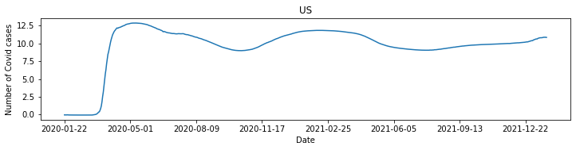

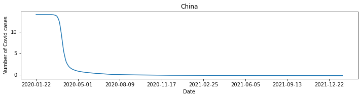

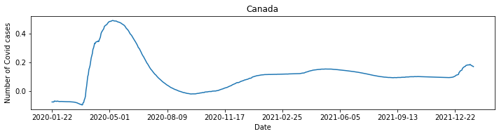

```python
#1.3 Run the function in step 1 on the standardized dataset for the US, China, and Canada
my_plot(['US','China','Canada'],3,cases_scaled)
```

### 1.4 Discuss the trends in the standardized time-series for the US, Canada, and China. What does it mean if the curve goes up or down (are the number of covid cases negative?) What does the sign of values indicate?

# Part 2: Applying PCA [3 Marks]

1. Compute the covariance matrix of the dataframe. *Hint: The dimensions of your covariance matrix should be (733, 733).* **[0.5]**
2. Write a function `get_sorted_eigen(df_cov)` that gets the covariance matrix of dataframe `df` (from step 1), and returns sorted eigenvalues and eigenvectors using `np.linalg.eigh`. **[0.5]**
3. Show the effectiveness of your principal components in covering the variance of the dataset with a `scree plot`(Bars for each componenet and a line to show cumulative --similar to tutoriual. Limit x-axis if needed to better see the plot). **[0.5]**
4. How many PCs do you need to cover 98% of the dataset's variance? **[0.5]**
5. Plot the first 16 principal components (Eigenvectors) as a time series (16 subplots, on the x-axis you have dates and on the y-axis you have the value of the PC element) . **[0.5]**
6. Compare the first few PCs with the rest of them. Do you see any difference in their trend? **[0.5]**

```python
#2.1 Compute the covariance matrix of the dataframe
cases_cov = cases_scaled.cov()
cases_cov
```

|  | 2020-01-22 | 2020-01-23 | 2020-01-24 | 2020-01-25 | 2020-01-26 | 2020-01-27 | 2020-01-28 | 2020-01-29 | 2020-01-30 | 2020-01-31 | ... | 2022-01-14 | 2022-01-15 | 2022-01-16 | 2022-01-17 | 2022-01-18 | 2022-01-19 | 2022-01-20 | 2022-01-21 | 2022-01-22 | 2022-01-23 |
| --- | --- | --- | --- | --- | --- | --- | --- | --- | --- | --- | --- | --- | --- | --- | --- | --- | --- | --- | --- | --- | --- |
| 2020-01-22 | 1.005128 | 1.005121 | 1.005114 | 1.005111 | 1.005113 | 1.005110 | 1.005111 | 1.005109 | 1.005106 | 1.005108 | ... | -0.017397 | -0.017426 | -0.017426 | -0.017428 | -0.017393 | -0.017399 | -0.017428 | -0.017435 | -0.017479 | -0.017525 |
| 2020-01-23 | 1.005121 | 1.005128 | 1.005121 | 1.005116 | 1.005117 | 1.005114 | 1.005114 | 1.005112 | 1.005110 | 1.005112 | ... | -0.017622 | -0.017650 | -0.017650 | -0.017653 | -0.017617 | -0.017624 | -0.017654 | -0.017661 | -0.017705 | -0.017751 |
| 2020-01-24 | 1.005114 | 1.005121 | 1.005128 | 1.005121 | 1.005120 | 1.005117 | 1.005115 | 1.005113 | 1.005110 | 1.005112 | ... | -0.016902 | -0.016924 | -0.016919 | -0.016922 | -0.016878 | -0.016878 | -0.016901 | -0.016903 | -0.016941 | -0.016981 |
| 2020-01-25 | 1.005111 | 1.005116 | 1.005121 | 1.005128 | 1.005125 | 1.005123 | 1.005121 | 1.005121 | 1.005119 | 1.005119 | ... | -0.017423 | -0.017446 | -0.017441 | -0.017446 | -0.017404 | -0.017407 | -0.017430 | -0.017433 | -0.017471 | -0.017512 |
| 2020-01-26 | 1.005113 | 1.005117 | 1.005120 | 1.005125 | 1.005128 | 1.005127 | 1.005124 | 1.005123 | 1.005122 | 1.005122 | ... | -0.016759 | -0.016781 | -0.016777 | -0.016777 | -0.016734 | -0.016736 | -0.016760 | -0.016764 | -0.016804 | -0.016846 |
| ... | ... | ... | ... | ... | ... | ... | ... | ... | ... | ... | ... | ... | ... | ... | ... | ... | ... | ... | ... | ... | ... |
| 2022-01-19 | -0.017399 | -0.017624 | -0.016878 | -0.017407 | -0.016736 | -0.017320 | -0.017977 | -0.017906 | -0.018090 | -0.017984 | ... | 1.004950 | 1.005001 | 1.005036 | 1.005067 | 1.005113 | 1.005128 | 1.005119 | 1.005097 | 1.005065 | 1.005026 |
| 2022-01-20 | -0.017428 | -0.017654 | -0.016901 | -0.017430 | -0.016760 | -0.017346 | -0.018003 | -0.017932 | -0.018116 | -0.018010 | ... | 1.004874 | 1.004939 | 1.004985 | 1.005022 | 1.005086 | 1.005119 | 1.005128 | 1.005120 | 1.005102 | 1.005075 |
| 2022-01-21 | -0.017435 | -0.017661 | -0.016903 | -0.017433 | -0.016764 | -0.017350 | -0.018008 | -0.017938 | -0.018122 | -0.018017 | ... | 1.004779 | 1.004856 | 1.004912 | 1.004957 | 1.005044 | 1.005097 | 1.005120 | 1.005128 | 1.005119 | 1.005100 |
| 2022-01-22 | -0.017479 | -0.017705 | -0.016941 | -0.017471 | -0.016804 | -0.017390 | -0.018049 | -0.017978 | -0.018162 | -0.018057 | ... | 1.004710 | 1.004802 | 1.004868 | 1.004909 | 1.005003 | 1.005065 | 1.005102 | 1.005119 | 1.005128 | 1.005122 |
| 2022-01-23 | -0.017525 | -0.017751 | -0.016981 | -0.017512 | -0.016846 | -0.017434 | -0.018093 | -0.018022 | -0.018207 | -0.018102 | ... | 1.004632 | 1.004735 | 1.004809 | 1.004848 | 1.004954 | 1.005026 | 1.005075 | 1.005100 | 1.005122 | 1.005128 |

733 rows × 733 columns

```python
# 2.2 Write a function that returns sorted eigenvalues and eigenvectors using np.linalg.eigh.
import numpy as np
def get_sorted_eigen(df_cov):
    # Eigen decomposition
    eigenValues, eigenVectors = np.linalg.eigh(df_cov)
    args = (-eigenValues).argsort()
    eigenValues = eigenValues[args]
    eigenVectors = eigenVectors[:, args]
    return eigenValues,eigenVectors
```

```python
# 2.2 apply the function on 'cases_cov'
get_sorted_eigen(cases_cov)
```

```
(array([ 6.29751397e+02,  6.35799591e+01,  2.93548081e+01,  8.92132873e+00,
         2.63636494e+00,  1.12487598e+00,  4.65343576e-01,  3.26308441e-01,
         1.89140012e-01,  1.63513238e-01,  7.41120116e-02,  5.03344793e-02,
         3.34251099e-02,  2.69142030e-02,  1.68740230e-02,  1.00557663e-02,
         8.05593098e-03,  5.39064498e-03,  4.65013360e-03,  3.30075098e-03,
         2.88730425e-03,  2.07690556e-03,  1.80618514e-03,  1.27833981e-03,
         8.06147091e-04,  6.24374956e-04,  5.72089628e-04,  4.60243047e-04,
         3.69968039e-04,  3.08315861e-04,  2.34934402e-04,  2.15716465e-04,
         1.51783209e-04,  1.32028271e-04,  1.17830212e-04,  1.04517227e-04,
         8.46868130e-05,  7.24064596e-05,  5.84238039e-05,  4.83233886e-05,
         4.70855183e-05,  4.47992385e-05,  3.58380151e-05,  3.20686095e-05,
         2.87702340e-05,  2.34221449e-05,  1.98742999e-05,  1.62816868e-05,
         1.59541740e-05,  1.56964435e-05,  1.32109425e-05,  1.22883112e-05,
         1.08733567e-05,  8.73815588e-06,  8.44234307e-06,  7.21350315e-06,
         6.95595929e-06,  6.06585129e-06,  4.77112280e-06,  4.26124691e-06,
         3.85380417e-06,  3.61476302e-06,  3.30349343e-06,  2.99041994e-06,
         2.76773911e-06,  2.33036589e-06,  2.11512102e-06,  1.88620882e-06,
         1.80482863e-06,  1.66604507e-06,  1.47929290e-06,  1.41060886e-06,
         1.26405187e-06,  1.18677845e-06,  1.09396685e-06,  1.03261265e-06,
         1.00941606e-06,  9.25745610e-07,  8.51024759e-07,  7.92282989e-07,
         7.63242375e-07,  6.61750377e-07,  6.25619956e-07,  6.07636563e-07,
         5.66792472e-07,  5.23789262e-07,  4.97195630e-07,  4.67846606e-07,
         4.34444668e-07,  4.17056871e-07,  3.75315506e-07,  3.58871926e-07,
         3.34912508e-07,  3.13551569e-07,  2.97651746e-07,  2.76739001e-07,
         2.71056658e-07,  2.51066212e-07,  2.40069096e-07,  2.15447860e-07,
         2.04641441e-07,  1.95676563e-07,  1.72065923e-07,  1.61802647e-07,
         1.54901558e-07,  1.47732952e-07,  1.39619181e-07,  1.31973974e-07,
         1.23605648e-07,  1.12435292e-07,  1.06413024e-07,  9.73368625e-08,
         9.43848360e-08,  8.71208589e-08,  8.42224375e-08,  8.10104046e-08,
         7.75854648e-08,  7.48562807e-08,  6.37531034e-08,  5.39332731e-08,
         5.28928069e-08,  5.09147184e-08,  4.72225682e-08,  4.61651131e-08,
         4.37024303e-08,  4.16107205e-08,  4.01586612e-08,  3.77488411e-08,
         3.55116317e-08,  3.31736264e-08,  3.14779519e-08,  3.00570714e-08,
         2.76870627e-08,  2.67454847e-08,  2.48785540e-08,  2.33851229e-08,
         2.18017411e-08,  1.97151309e-08,  1.88243615e-08,  1.76861277e-08,
         1.62580568e-08,  1.41430977e-08,  1.29739713e-08,  1.28181568e-08,
         1.21415606e-08,  1.10214266e-08,  1.06468254e-08,  9.64728889e-09,
         8.37397900e-09,  8.05654709e-09,  7.87649018e-09,  7.41254020e-09,
         6.67770081e-09,  5.92168924e-09,  5.17729390e-09,  4.66541450e-09,
         4.37852802e-09,  4.16073980e-09,  3.90734520e-09,  3.46285099e-09,
```

[output cut: 142 more lines]

```
        -4.11249141e-14, -4.24605611e-14, -4.47952393e-14, -5.28657139e-14,
        -6.50987663e-14]),
 array([[ 7.59424602e-05,  1.21711020e-01, -4.06068889e-02, ...,
          0.00000000e+00,  0.00000000e+00, -0.00000000e+00],
        [ 6.57839673e-05,  1.21707808e-01, -4.06261870e-02, ...,
          5.90762335e-03,  3.25542431e-02, -2.75632213e-02],
        [ 9.16226464e-05,  1.21724974e-01, -4.05405387e-02, ...,
         -4.88657542e-03,  2.56091098e-03,  6.26497058e-02],
        ...,
        [ 3.95020907e-02, -6.24161862e-04,  8.10875226e-03, ...,
          1.64944482e-02,  4.50262928e-02,  3.49200703e-02],
        [ 3.94917946e-02, -6.36088813e-04,  7.87831025e-03, ...,
         -9.24817242e-03, -1.18346018e-02, -1.55590958e-02],
        [ 3.94823319e-02, -6.00418673e-04,  8.05737147e-03, ...,
         -3.29952377e-03,  1.08155115e-02,  1.74681135e-02]]))
```

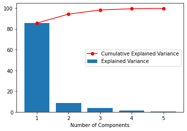

```python
#2.3 Show the effectiveness of your principal components in covering the variance of the dataset with a scree plot
#(Bars for each componenet and a line to show cumulative --similar to tutoriual. Limit x-axis if needed to better see the plot).

eigenValues = get_sorted_eigen(cases_cov)[0]
eigenVectors = get_sorted_eigen(cases_cov)[1]
#explained variance
eigValSum = sum(eigenValues)
expVar = [eigV/eigValSum*100 for eigV in eigenValues]
cumExpVar = np.cumsum(expVar)
plt.bar(np.arange(1,6), expVar[:5], label='Explained Variance')
plt.plot(np.arange(1,6),cumExpVar[:5], 'r-o', label='Cumulative Explained Variance')
plt.xlabel('Number of Components')
plt.legend()
plt.show()
```

```python
# 2.4 How many PCs do you need to cover 98% of the dataset's variance?
print(np.where(cumExpVar>=98)[0][0]+1,"PCs are needed to cover 98% of the dataset's variance.")
```

```
3 PCs are needed to cover 98% of the dataset's variance.
```

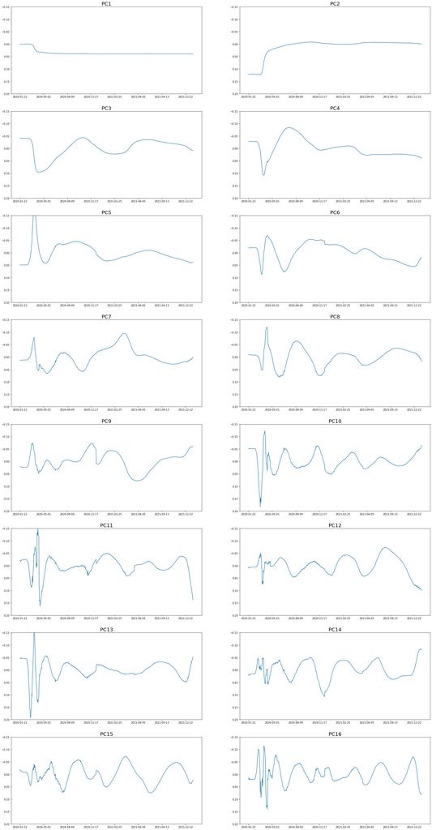

```python
#2.5 Plot the first 16 principal components (Eigenvectors) as a time series
#(16 subplots, on the x-axis you have dates and on the y-axis you have the value of the PC element)

xy=pd.DataFrame(eigenVectors,index = cases_cov.columns)
for i in range(16):
    plt.subplot(8, 2, i+1)
    xy.iloc[:,i].plot(figsize=(30,60))   #each column:each eigenvector
    plt.title('PC'+str(i+1),size=20)
    plt.ylim(0.2, -0.15)   #set the same range of y_axis, for a better comparison
```

### 2.6 Compare the first few PCs with the rest of them. Do you see any difference in their trend?

- We understand the directions of the spread of our data using Eigenvectors. The first several PC are more steady, and the rest of the graphs fluctuate more in both directions and magnitude if we compared with the first few PCs, which means there are more noise as the number of PC increases, like PC14,PC15 or PC16, and it is a bit harder to generalized the overall patterns.

# Part 3: Data reconstruction [5 Marks]

Create a function that:

- Accepts a country and the original dataset as inputs.
- Calls useful functions that you designed in previous parts to compute eigen vectors and eigen values.
- Plots 4 figures:
  1. The original time-series for the specified country. **[1]**
  2. The incremental reconstruction of the **original** (not standardized) time-series for the specified country in a single plot. **[1]**
     - You should at least show 5 curves in a figure for incremental reconstruction. For example, you can pick the following (or any other combination that you think is reasonable):
       - Reconstruction with only PC1
       - Reconstruction with both PC1 and PC2
       - Reconstruction with PC1 to PC4 (First 4 PCs)
       - Reconstruction with PC1 to PC8 (First 8 PCs)
       - Reconstruction with PC1 to PC16 (First 16 PCs)
     - Hint: you need to compute the reconstruction for the standardized time-series first, and then scale it back to the original (non-standardized form) using the StandardScaler `inverse_transform` [help...](https://scikit-learn.org/stable/modules/generated/sklearn.preprocessing.StandardScaler.html#sklearn.preprocessing.StandardScaler.inverse_transform)
  3. The residual error for your best reconstruction with respect to the original time-series. **[1]**
     - Hint: You are plotting the error that we have for reconstructing each day `(df - df_reconstructed)`. On the x-axis, you have dates, and on the y-axis, the residual error.
  4. The RMSE of the reconstruction as a function of the number of included components (x-axis is the number of components and y-axis is the RMSE). Sweep x-axis from 1 to 100 (this part is independent from part 3.2.) **[1]**

Test your function using the `US`, `Canada`, and `China` as inputs. **[1]**

```python
def PCA_plot(country_name):
    for PC_count in [1,2,4,8,16]:
        W = eigenVectors[:, 0:PC_count]
        projX = np.dot(cases_scaled, W)
        ReconX = np.dot(projX, W.T)
        # scale it back to the original (non-standardized form) using the StandardScaler inverse_transform
        ReconX_original = pd.DataFrame(scaler.inverse_transform(ReconX), columns=cases_raw.columns,index=cases_raw.index)
        ReconX_original.loc[country_name,:].plot(figsize=(10,10),label = 'With the first {} PC(s)'.format(PC_count),title='Reconstruction with PC(s)')
        plt.legend()

def error(country_name):
    W = eigenVectors[:, 0:16]   #as more PC==>more variance woule be explained, so choose best amount of PC to be 16
    projX = np.dot(cases_scaled, W)
    ReconX = np.dot(projX, W.T)
    ReconX_original = pd.DataFrame(scaler.inverse_transform(ReconX), columns=cases_raw.columns,index=cases_raw.index)
    (cases_raw.loc[country_name,:]-ReconX_original.loc[country_name,:]).plot(figsize=(10,10),title = 'Residual Error with the first 16 PCs')

from sklearn.metrics import mean_squared_error
def rmse(country_name):  #root mean sqaured error
    rmse=[]
    for i in range(1,101):  #sweep from 1 to 100
        W = eigenVectors[:, 0:i]
        projX = np.dot(cases_scaled, W)
        ReconX = np.dot(projX, W.T)
        ReconX_original = pd.DataFrame(scaler.inverse_transform(ReconX), columns=cases_raw.columns,index=cases_raw.index)
        rmse.append(mean_squared_error(cases_raw.loc[country_name,:], ReconX_original.loc[country_name,:], squared=False))
    plt.plot(np.arange(1,101),rmse)
    plt.title('RMSE of reconstruction')
    plt.xlabel('Number of Components Included(from 1 to 100)')
```

```python
def plot_country_figures(original_df, country_name):
    original_df_cov=original_df.cov()
    eigenValues = get_sorted_eigen(original_df_cov)[0]
    eigenVectors = get_sorted_eigen(original_df_cov)[1]  #call functions created before to compute eigen vectors and eigen values.

    plt.subplot(2,2,1)   #The original time-series for the specified country
    original_df.loc[country_name,:].plot(title='Original, in '+country_name)

    plt.subplot(2,2,2)   #The incremental reconstruction of the original time-series for the specified country in a single plot
    PCA_plot(country_name)

    plt.subplot(2,2,3) #The residual error for your best reconstruction with respect to the original time-series.
    error(country_name)

    plt.subplot(2,2,4) # RMSE of the reconstruction as a function of the number of included components
    rmse(country_name)
```

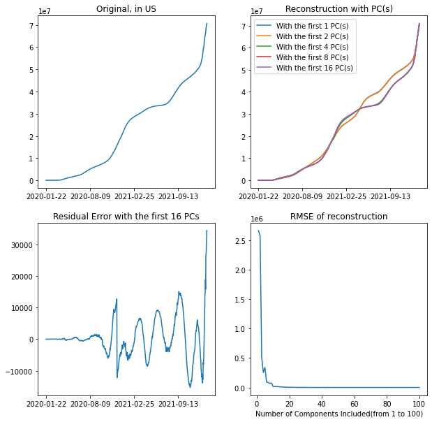

```python
#Test your function using the US, Canada, and China as inputs.
plot_country_figures(cases_raw, 'US')
```

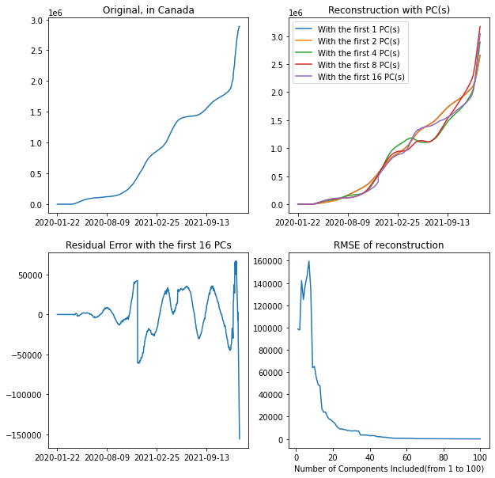

```python
plot_country_figures(cases_raw, 'Canada')
```

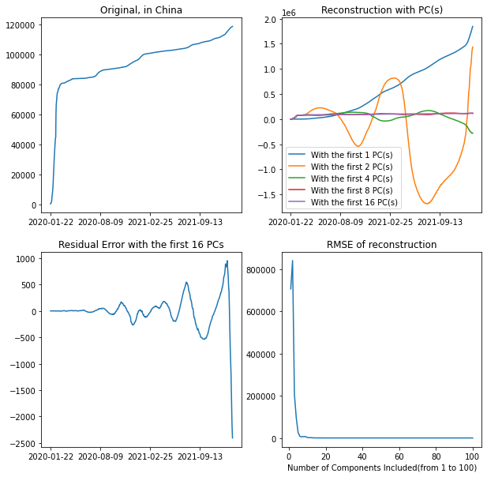

```python
plot_country_figures(cases_raw, 'China')
```

# Part 4: Fashion-MNIST dataset [4 Marks]

Fashion-MNIST is a dataset for clothes. Each image in Fashion-MNIST has 28x28 pixels which can be represented in an array with 784 elements. You can take a better look at this dataset in this [link](https://www.openml.org/d/40996)

In this part, we are going to use PCA to compress these images. The $x$ matrix below has 1000 images.

- Create a new dataset by selecting images from *only* three categories (three distinct labels).
  - To compress and reconstruct images better with PCA, it is better to choose items that are similar in shape. why? **[0.5]**
- Compute Eigenvectors and Eigenvalues. **[0.5]**
- Plot the first 10 eigenvectors (as images similar to eigenfaces). What trends do you observe? **[0.5]**
- Create a function that requires an argument $n$ and plots a random image from the dataset, as well as a reconstruction with the first $n$ th principal components. **[1]**
- Run your function a few times, and determine how many components are required so that we (humans!) can identify the items. **[0.5]**
- Assume you want to share this dataset with someone else. Instead of directly giving them the whole dataset, you can share the eigenvectors (some of them) and projections with them, and thay can do a dot product to get the reconstructions. Based on the number of components that you found in the last step, what would be the compression ratio for a dataset with 1000 images? **[1]**
  - Hint: compare the dataset size with a case where we only use some principal components and projections.

```python
from sklearn.datasets import fetch_openml
mnist = fetch_openml("Fashion-MNIST")
x = mnist.data[0:1000]
y = mnist.target[0:1000]
target_encoding = {0: "T-shirt/top",
1: "Trouser",
2: "Pullover",
3: "Dress",
4: "Coat",
5: "Sandal",
6: "Shirt",
7: "Sneaker",
8: "Bag",
9: "Ankle boot"}
```

```python
x.shape
```

```
(1000, 784)
```

```
Label is: Ankle boot
```

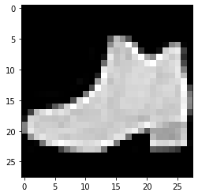

```python
import matplotlib.pyplot as plt
plt.gray()
ind = 15
plt.imshow(x.loc[ind].values.reshape(28,28))
print ("Label is:", target_encoding[int(y[ind])])
plt.show()
```

```python
# 4.1 Create a new dataset by selecting images from only three categories
# 7: "Sneaker",5: "Sandal", 9: "Ankle boot", as they are so similar that not easy to be seperated as images,
# they are chosed to be compressed and reconstruct images better with PCA.
y_shoes = y[(y== '5') | (y== '7') | (y== '9')]
x_shoes = x.loc[y_shoes.index.values]
```

#### Choose 7: "Sneaker",5: "Sandal", 9: "Ankle boot".

If we want to reconstruct images better with PCA, we want to compress the ones that are similar that the images are not easily to be seperated, so that we can be more sure to seperate the overall dataset afterward.

```python
#4.2 Compute Eigenvectors and Eigenvalues
def getBasisCountThatPreservesVariance(eigenValues, variance=0.98):
    for idx, cumulativeSum in enumerate(np.cumsum(eigenValues) / np.sum(eigenValues)):
        if cumulativeSum > variance:
            return idx

def pca(X, y):
    n, d = X.shape
    mu = X.mean(axis=0)
    X = X - mu # standardising data

    if n > d:    #sample>feature, don't used in the new sample with 314 samples actually.
        C = np.dot(X.T,X) / (n-1) # covariance matrix
        eigenValues, eigenVectors = np.linalg.eigh(C)
    else:               #we choose this one, as only 314 samples of shoes.
        C = np.dot(X,X.T) / (n-1) # covariance matrix
        eigenValues, eigenVectors = np.linalg.eigh(C)
        eigenVectors = np.dot(X.T, eigenVectors)
        for i in range(n):
            eigenVectors[:,i] = eigenVectors[:, i] / np.linalg.norm(eigenVectors[:, i])

    print ("Dim of Full Eigen Vectors", eigenVectors.shape)

    # sort eigenVectors in descending order by their eigenValue ==> by level of importance
    idx = np.argsort(-eigenValues)
    eigenValues = eigenValues[idx]
    eigenVectors = eigenVectors[:, idx]

    # select based on numOfBasis ===> number of PC you need to achive the variance
    numOfBasis = getBasisCountThatPreservesVariance(eigenValues)
    print('Number of useful eigenBasis are: ', numOfBasis)
    eigenValues = eigenValues[0:numOfBasis].copy()
    eigenVectors = eigenVectors[:, 0:numOfBasis].copy()
    return eigenValues, eigenVectors, mu
```

```python
eigenValues, eigenVectors, mean = pca(x_shoes, y_shoes)
#eigenValues, if you want to print them
#eigenVectors
```

```
Dim of Full Eigen Vectors (784, 314)
Number of useful eigenBasis are:  148
```

```python
eigenValues.shape , eigenVectors.shape
```

```
((148,), (784, 148))
```

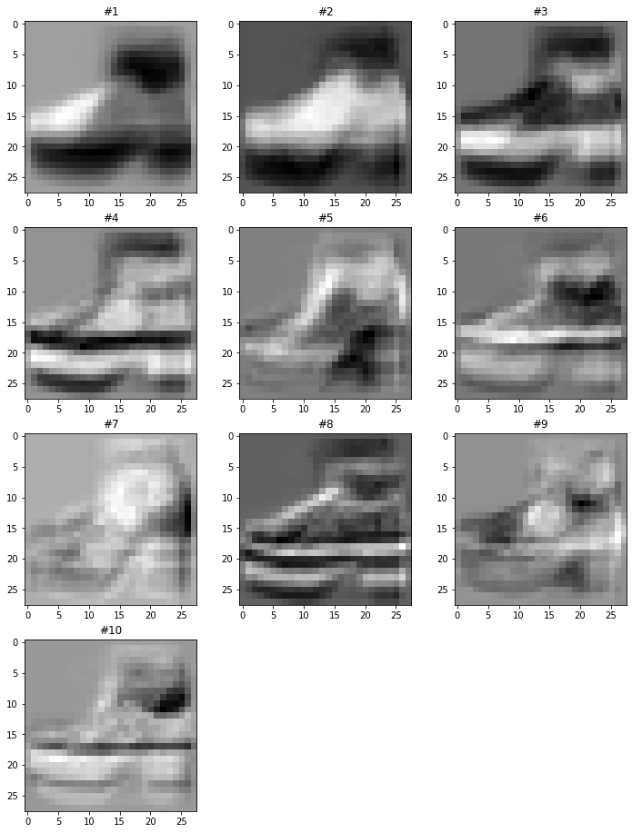

```python
# 4.3 Plot the first 10 eigenvectors (as images similar to eigenfaces). What trends do you observe?
import math
COUNT = 10
ROWS = math.ceil(COUNT/3)
fig = plt.figure(figsize=(12, ROWS * 4))
for i in range(0, COUNT):
    plt.subplot(ROWS, 3, i+1)
    plt.imshow(eigenVectors[:, i].reshape(-1, 28), cmap = plt.cm.gray)
    plt.title('#{}'.format(i+1))
```